# Why Did Counties Flip From 2016 to 2020?

For our CS 109a final project, we aimed to analyze why counties flipped (Democrat to Republican, or vice versa) between the 2016 and 2020 presidential election cycles. To do so, we first parsed our data and performed an exploratory data analysis (EDA). Next, we used a Lasso model to identify the top features of our data. Finally, we present visualizations of the top features that contribute to why counties flipped from one party to another.

- Data Processing
- EDA
- Data Analysis (PCA/Lasso/Decision Tree)
- Prediction (Random Forest/Gradient Boosting))

# Flowchart

[figure not shown]

# Libraries

For this project, we import `pandas` and `numpy` to efficiently process data frames and arrays, `matplotlib` and `seaborn` for plotting, and `prettytable` to format tables nicely. In addition, we import various `scikit-learn` machine learning tools to make inferences about the data.

# Data Handling

Our data, found in the `data` folder, came from two sources. First, we used the MIT Elections Lab to download presidential results by county. This dataset includes rows with county names, political parties, and vote totals, along with other information. Next, we downloaded data from the US Census Bureau from 2016 and 2021 linking counties to a wide variety of metrics over time. These metrics include income levels, demographics, and other factors.

In this step, we import all of the data we plan to use in our project, parse and manipulate the data to a more convenient format, and perform different analysis steps to attempt to determine the most important factors in predicting whether a county would flip between 2016 and 2020.

Our processing pipeline was the most involved part of this milestone. It involved the following steps:

## Standardization

Since we pulled from two different data sources — the MIT Elections Lab and the US Census — we needed to standardize the data in order to relate the two datasets. This involved parsing the more detailed county names from the MIT Elections lab, accounting for differences in capitlization, and performing a Pandas DataFrame `merge` operation to combine the data.

After this, we added a `year` column to the election result data, removed unnecessary rows, and finally used scaling and missingness techniques to further regularize the data.

## Scaling, Missingness

```python
# Import Pandas.
import pandas as pd
import seaborn as sns
import numpy as np
import matplotlib.pyplot as plt
from sklearn.preprocessing import StandardScaler
from sklearn.decomposition import PCA
from sklearn import linear_model
from sklearn.tree import DecisionTreeRegressor
from sklearn.ensemble import GradientBoostingRegressor
from sklearn.model_selection import train_test_split
from sklearn.ensemble import RandomForestRegressor
from sklearn.metrics import mean_squared_error, r2_score
from prettytable import PrettyTable
```

## Loading Presidential Results

In this section, we load and filter the Presidential election results.

```python
# Load results data.
pres_df = pd.read_csv('data/countypres_2000-2020.csv')
```

```python
# Filter to 2016 or 2020
pres_df = pres_df[(pres_df['year'] == 2020) | (pres_df['year'] == 2016)]
```

```python
# Preview
pres_df.head()
```

|  | year | state | state_po | county_name | county_fips | office | candidate | party | candidatevotes | totalvotes | version | mode |
| --- | --- | --- | --- | --- | --- | --- | --- | --- | --- | --- | --- | --- |
| 40517 | 2016 | ALABAMA | AL | AUTAUGA | 1001.0 | US PRESIDENT | HILLARY CLINTON | DEMOCRAT | 5936 | 24973 | 20220315 | TOTAL |
| 40518 | 2016 | ALABAMA | AL | AUTAUGA | 1001.0 | US PRESIDENT | DONALD TRUMP | REPUBLICAN | 18172 | 24973 | 20220315 | TOTAL |
| 40519 | 2016 | ALABAMA | AL | AUTAUGA | 1001.0 | US PRESIDENT | OTHER | OTHER | 865 | 24973 | 20220315 | TOTAL |
| 40520 | 2016 | ALABAMA | AL | BALDWIN | 1003.0 | US PRESIDENT | HILLARY CLINTON | DEMOCRAT | 18458 | 95215 | 20220315 | TOTAL |
| 40521 | 2016 | ALABAMA | AL | BALDWIN | 1003.0 | US PRESIDENT | DONALD TRUMP | REPUBLICAN | 72883 | 95215 | 20220315 | TOTAL |

## Loading Census Data

In this section, we load the census data to a dictionary before manipulating it.

```python
# Load census data.
census_df_dict = {
  '2016': [
    pd.read_csv('data/ACSDP1Y2016.DP02-Data.csv'),
    pd.read_csv('data/ACSDP1Y2016.DP03-Data.csv'),
    pd.read_csv('data/ACSDP1Y2016.DP04-Data.csv'),
    pd.read_csv('data/ACSDP1Y2016.DP05-Data.csv'),
  ],
  '2020': [
    pd.read_csv('data/ACSDP1Y2021.DP02-Data.csv'),
    pd.read_csv('data/ACSDP1Y2021.DP03-Data.csv'),
    pd.read_csv('data/ACSDP1Y2021.DP04-Data.csv'),
    pd.read_csv('data/ACSDP1Y2021.DP05-Data.csv'),
  ]
}
```

```python
# Make a list of census DataFrames.
census_df_list = []

# Add to the list, including the corresponding year as a column in each DF.
for key in census_df_dict:
  for df in census_df_dict[key]:
    df['STD_YEAR'] = int(key)
    census_df_list.append(df)
```

```python
import pandas as pd

# Assuming pres_df is your filtered election data
# Calculate total votes for each party in each county
party_votes = pres_df.groupby(['year', 'county_fips', 'party'])['candidatevotes'].sum().unstack()
party_votes['total_votes'] = party_votes.sum(axis=1)
party_votes['dem_percent'] = (party_votes['DEMOCRAT'] / party_votes['total_votes']) * 100
party_votes['rep_percent'] = (party_votes['REPUBLICAN'] / party_votes['total_votes']) * 100

# Reset index for easier plotting
party_votes = party_votes.reset_index()
```

```python
# Standardize the "Geographic Area Name" of a given row into an all-caps
# county name.
def standardize_row_gan(row):
  if ' County,' in row['Geographic Area Name']:
    end_index = row['Geographic Area Name'].index(' County,')
    return row['Geographic Area Name'][0:end_index].upper()
  else:
    return row['Geographic Area Name']

# Mergs a list of census DataFrames, each with different census data columns,
# into a single DF.
def standardize_census_dfs(dfs):
  df = dfs[0]

  # Merge according to county.
  for other_df in dfs[1:]:
    df = df.merge(other_df, on='Geographic Area Name', how='outer', suffixes=(None, '!!y'))

  # Standardize county names.
  df['STD_COUNTY'] = df.apply(standardize_row_gan, axis=1)

  # Remove duplicate columns, which we delimited earlier with the `!!y` suffix.
  to_drop = []
  for column in df:
    if column.endswith('!!y'):
      to_drop.append(column)
  df = df.drop(to_drop, axis=1)

  return df

# Standardize into a single Census DataFrame.
census_df = standardize_census_dfs(census_df_list)
```

```python
census_df.head()
```

|  | Geography | Geographic Area Name | Estimate!!HOUSEHOLDS BY TYPE!!Total households | Margin of Error!!HOUSEHOLDS BY TYPE!!Total households | Percent!!HOUSEHOLDS BY TYPE!!Total households | Percent Margin of Error!!HOUSEHOLDS BY TYPE!!Total households | Estimate!!HOUSEHOLDS BY TYPE!!Total households!!Family households (families) | Margin of Error!!HOUSEHOLDS BY TYPE!!Total households!!Family households (families) | Percent!!HOUSEHOLDS BY TYPE!!Total households!!Family households (families) | Percent Margin of Error!!HOUSEHOLDS BY TYPE!!Total households!!Family households (families) | ... | Percent!!Race alone or in combination with one or more other races!!Total population!!American Indian and Alaska Native | Percent Margin of Error!!Race alone or in combination with one or more other races!!Total population!!American Indian and Alaska Native | Percent!!Race alone or in combination with one or more other races!!Total population!!Asian | Percent Margin of Error!!Race alone or in combination with one or more other races!!Total population!!Asian | Percent!!Race alone or in combination with one or more other races!!Total population!!Native Hawaiian and Other Pacific Islander | Percent Margin of Error!!Race alone or in combination with one or more other races!!Total population!!Native Hawaiian and Other Pacific Islander | Percent!!Race alone or in combination with one or more other races!!Total population!!Some other race | Percent Margin of Error!!Race alone or in combination with one or more other races!!Total population!!Some other race | Unnamed: 358 | STD_COUNTY |
| --- | --- | --- | --- | --- | --- | --- | --- | --- | --- | --- | --- | --- | --- | --- | --- | --- | --- | --- | --- | --- | --- |
| 0 | 0500000US01003 | Baldwin County, Alabama | 76779.0 | 3010.0 | 76779.0 | (X) | 49943.0 | 3287.0 | 65.0 | 3.2 | ... | 1.6 | 0.3 | 1.5 | 0.2 | N | N | 4.7 | 1.1 | NaN | BALDWIN |
| 1 | 0500000US01015 | Calhoun County, Alabama | 43972.0 | 1687.0 | 43972.0 | (X) | 30403.0 | 1889.0 | 69.1 | 3.2 | ... | 3.9 | 1.9 | 1.7 | 0.5 | N | N | 4.4 | 1.0 | NaN | CALHOUN |
| 2 | 0500000US01043 | Cullman County, Alabama | 30299.0 | 1234.0 | 30299.0 | (X) | 21551.0 | 1384.0 | 71.1 | 4.0 | ... | 1.4 | 0.3 | 0.8 | 0.6 | N | N | 4.7 | 0.6 | NaN | CULLMAN |
| 3 | 0500000US01049 | DeKalb County, Alabama | 25383.0 | 1190.0 | 25383.0 | (X) | 18834.0 | 1335.0 | 74.2 | 4.1 | ... | 5.5 | 1.9 | N | N | N | N | 10.6 | 2.8 | NaN | DEKALB |
| 4 | 0500000US01051 | Elmore County, Alabama | 29350.0 | 1102.0 | 29350.0 | (X) | 21413.0 | 1872.0 | 73.0 | 5.0 | ... | 1.1 | 0.3 | N | N | N | N | 1.7 | 0.9 | NaN | ELMORE |

5 rows × 2802 columns

## Standardizing Census DF

Standardize the Census DF data according to the steps described above. Note that we ignore any Census data that starts with "Margin of Error" or "Percent Margin of Error," as these do not reflect data that should influence election results.

```python
from pandas.api.types import is_numeric_dtype
from sklearn.preprocessing import StandardScaler
from sklearn.impute import SimpleImputer
import numpy as np

columns = census_df.columns

# Iterate over columns...
for column in columns:
  # Only the numeric ones that are not already standardized and have some values.
  if is_numeric_dtype(census_df[column]) \
    and not column.startswith('STD_') \
    and not column.startswith('Percent Margin of Error!!') \
    and not column.startswith('Margin of Error!!') \
    and np.sum(pd.notna(census_df[column])) > 0:
    # Use the SimpleImputer and StandardScalar as described above.
    census_df['IMP_' + column] = SimpleImputer().fit_transform(census_df[[column]]).reshape((-1))
    census_df['STD_' + column] = StandardScaler().fit_transform(census_df[['IMP_' + column]]).reshape((-1))
```

## Presidential Election Standardization

We also standardize the Presidential Election results into a single meaningful float, `fraction_dem`, reflecting what fraction of votes the Democrats earned.

```python
def compute_fraction_votes(row):
  if row['totalvotes'] > 0:
    return row['candidatevotes'] / row['totalvotes']
  else:
    return 0

# Filter to Democratic results, then compute the `fraction_dem`.
pres_df_dems = pres_df[pres_df['party'] == 'DEMOCRAT']
pres_df_dems['fraction_dem'] = pres_df_dems.apply(compute_fraction_votes, axis=1)
```

```python
pres_df_dems.head()
```

|  | year | state | state_po | county_name | county_fips | office | candidate | party | candidatevotes | totalvotes | version | mode | fraction_dem |
| --- | --- | --- | --- | --- | --- | --- | --- | --- | --- | --- | --- | --- | --- |
| 40517 | 2016 | ALABAMA | AL | AUTAUGA | 1001.0 | US PRESIDENT | HILLARY CLINTON | DEMOCRAT | 5936 | 24973 | 20220315 | TOTAL | 0.237697 |
| 40520 | 2016 | ALABAMA | AL | BALDWIN | 1003.0 | US PRESIDENT | HILLARY CLINTON | DEMOCRAT | 18458 | 95215 | 20220315 | TOTAL | 0.193856 |
| 40523 | 2016 | ALABAMA | AL | BARBOUR | 1005.0 | US PRESIDENT | HILLARY CLINTON | DEMOCRAT | 4871 | 10469 | 20220315 | TOTAL | 0.465278 |
| 40526 | 2016 | ALABAMA | AL | BIBB | 1007.0 | US PRESIDENT | HILLARY CLINTON | DEMOCRAT | 1874 | 8819 | 20220315 | TOTAL | 0.212496 |
| 40529 | 2016 | ALABAMA | AL | BLOUNT | 1009.0 | US PRESIDENT | HILLARY CLINTON | DEMOCRAT | 2156 | 25588 | 20220315 | TOTAL | 0.084258 |

## Merging Data

Finally, we merge the data by finding the matching county and year in the `pres_df_dems` DataFrame for each row of the `census_df` DataFrame.

```python
merged_df = census_df.copy()
```

```python
# Finds the fraction of Democrat votes for a given county of census data.
def apply_vote_result(row):
  matching_pres_row = pres_df_dems[(pres_df_dems['year'] == row['STD_YEAR']) & (pres_df_dems['county_name'] == row['STD_COUNTY'])]
  if not matching_pres_row.empty:
    return matching_pres_row.iloc[0]['fraction_dem']
  return 0

# Integrate the fraction of Democrat votes as the `STD_Fraction_Dem` key
merged_df['STD_Fraction_Dem'] = merged_df.apply(apply_vote_result, axis=1)
merged_df.head()
```

|  | Geography | Geographic Area Name | Estimate!!HOUSEHOLDS BY TYPE!!Total households | Margin of Error!!HOUSEHOLDS BY TYPE!!Total households | Percent!!HOUSEHOLDS BY TYPE!!Total households | Percent Margin of Error!!HOUSEHOLDS BY TYPE!!Total households | Estimate!!HOUSEHOLDS BY TYPE!!Total households!!Family households (families) | Margin of Error!!HOUSEHOLDS BY TYPE!!Total households!!Family households (families) | Percent!!HOUSEHOLDS BY TYPE!!Total households!!Family households (families) | Percent Margin of Error!!HOUSEHOLDS BY TYPE!!Total households!!Family households (families) | ... | STD_Percent!!SEX AND AGE!!Total population!!65 years and over.1 | IMP_Percent!!SEX AND AGE!!Total population!!65 years and over!!Male | STD_Percent!!SEX AND AGE!!Total population!!65 years and over!!Male | IMP_Percent!!SEX AND AGE!!Total population!!65 years and over!!Female | STD_Percent!!SEX AND AGE!!Total population!!65 years and over!!Female | IMP_Percent!!Race alone or in combination with one or more other races!!Total population | STD_Percent!!Race alone or in combination with one or more other races!!Total population | IMP_Percent!!Race alone or in combination with one or more other races!!Total population!!White | STD_Percent!!Race alone or in combination with one or more other races!!Total population!!White | STD_Fraction_Dem |
| --- | --- | --- | --- | --- | --- | --- | --- | --- | --- | --- | --- | --- | --- | --- | --- | --- | --- | --- | --- | --- | --- |
| 0 | 0500000US01003 | Baldwin County, Alabama | 76779.0 | 3010.0 | 76779.0 | (X) | 49943.0 | 3287.0 | 65.0 | 3.2 | ... | -0.047579 | 48.1 | 1.709872 | 51.9 | -1.709872 | 239294.0 | -0.171172 | 87.6 | 0.543719 | 0.193856 |
| 1 | 0500000US01015 | Calhoun County, Alabama | 43972.0 | 1687.0 | 43972.0 | (X) | 30403.0 | 1889.0 | 69.1 | 3.2 | ... | -0.393115 | 43.6 | -0.891853 | 56.4 | 0.891853 | 115972.0 | -0.384077 | 75.4 | -0.239801 | 0.276659 |
| 2 | 0500000US01043 | Cullman County, Alabama | 30299.0 | 1234.0 | 30299.0 | (X) | 21551.0 | 1384.0 | 71.1 | 4.0 | ... | -0.442314 | 45.2 | 0.033205 | 54.8 | -0.033205 | 89496.0 | -0.429786 | 94.4 | 0.980434 | 0.100283 |
| 3 | 0500000US01049 | DeKalb County, Alabama | 25383.0 | 1190.0 | 25383.0 | (X) | 18834.0 | 1335.0 | 74.2 | 4.1 | ... | -0.492667 | 46.6 | 0.842630 | 53.4 | -0.842630 | 71813.0 | -0.460314 | 87.2 | 0.518029 | 0.140246 |
| 4 | 0500000US01051 | Elmore County, Alabama | 29350.0 | 1102.0 | 29350.0 | (X) | 21413.0 | 1872.0 | 73.0 | 5.0 | ... | -0.465121 | 44.2 | -0.544956 | 55.8 | 0.544956 | 89304.0 | -0.430117 | 77.7 | -0.092089 | 0.226597 |

5 rows × 4263 columns

# EDA

We plot percent change in Democratic vote totals against percent change in Republican vote totals. Each data point represents a county.

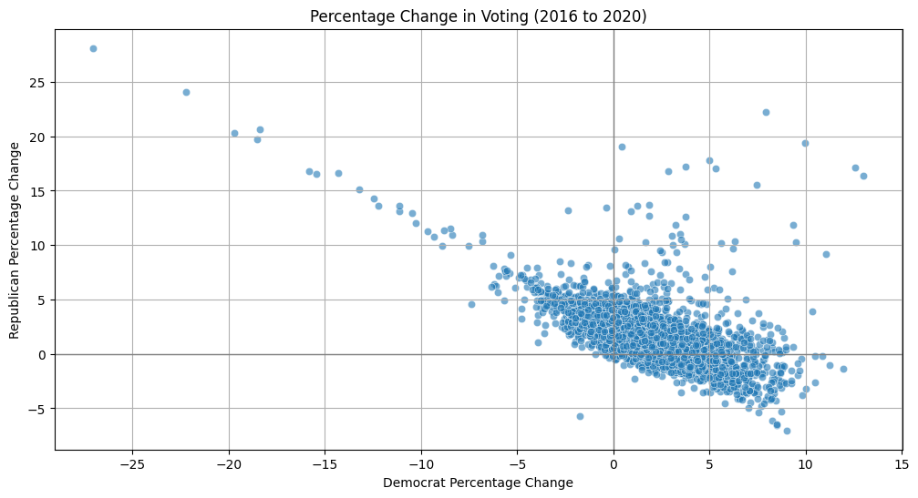

```python
pivot_votes = party_votes.pivot(index='county_fips', columns='year', values=['dem_percent', 'rep_percent'])

pivot_votes['dem_percent_change'] = (pivot_votes['dem_percent'][2020] - pivot_votes['dem_percent'][2016])
pivot_votes['rep_percent_change'] = (pivot_votes['rep_percent'][2020] - pivot_votes['rep_percent'][2016])

plt.figure(figsize=(12, 6))
sns.scatterplot(data=pivot_votes, x='dem_percent_change', y='rep_percent_change', alpha=0.6)
plt.title('Percentage Change in Voting (2016 to 2020)')
plt.xlabel('Democrat Percentage Change')
plt.ylabel('Republican Percentage Change')
plt.axhline(0, color='grey', lw=1)
plt.axvline(0, color='grey', lw=1)
plt.grid(True)
plt.show()
```

If it were the case that there not significant changes in voter turnout, and most votes were the result of a switch in parties, you would expect the line of best fit to be along y = -x. This data indicates that voter turnout increased. For example, a counties with a Democrat vote increase of 2.5% from 2016 to 2020 would also be expected to have a slightly higher Republic vote as well. While this effect diminished for higher percent changes, it was still not equivalent. For example, a 7.5% increased in Democratic votes was associated with a -2.5% decrease in Republican votes.

```python
# Extract X and y keys to use for the Lasso model, taking only the standardized keys.
x_keys = [col for col in merged_df if col.startswith('STD_') and not col == 'STD_YEAR' and not col == 'STD_Fraction_Dem' and not col == 'STD_COUNTY']
y_key = 'STD_Fraction_Dem'
merged_df[x_keys].head()
```

|  | STD_Estimate!!HOUSEHOLDS BY TYPE!!Total households | STD_Percent!!HOUSEHOLDS BY TYPE!!Total households | STD_Estimate!!HOUSEHOLDS BY TYPE!!Total households!!Family households (families) | STD_Percent!!HOUSEHOLDS BY TYPE!!Total households!!Family households (families) | STD_Estimate!!HOUSEHOLDS BY TYPE!!Total households!!Family households (families)!!Married-couple family | STD_Percent!!HOUSEHOLDS BY TYPE!!Total households!!Family households (families)!!Married-couple family | STD_Estimate!!HOUSEHOLDS BY TYPE!!Total households!!Family households (families)!!Male householder, no wife present, family | STD_Percent!!HOUSEHOLDS BY TYPE!!Total households!!Family households (families)!!Male householder, no wife present, family | STD_Estimate!!HOUSEHOLDS BY TYPE!!Total households!!Family households (families)!!Female householder, no husband present, family | STD_Percent!!HOUSEHOLDS BY TYPE!!Total households!!Family households (families)!!Female householder, no husband present, family | ... | STD_Percent!!SEX AND AGE!!Total population!!62 years and over | STD_Percent!!SEX AND AGE!!Total population!!65 years and over | STD_Percent!!SEX AND AGE!!Total population!!18 years and over.1 | STD_Percent!!SEX AND AGE!!Total population!!18 years and over!!Male | STD_Percent!!SEX AND AGE!!Total population!!18 years and over!!Female | STD_Percent!!SEX AND AGE!!Total population!!65 years and over.1 | STD_Percent!!SEX AND AGE!!Total population!!65 years and over!!Male | STD_Percent!!SEX AND AGE!!Total population!!65 years and over!!Female | STD_Percent!!Race alone or in combination with one or more other races!!Total population | STD_Percent!!Race alone or in combination with one or more other races!!Total population!!White |
| --- | --- | --- | --- | --- | --- | --- | --- | --- | --- | --- | --- | --- | --- | --- | --- | --- | --- | --- | --- | --- | --- |
| 0 | -0.227723 | -0.227723 | -0.229006 | -0.166452 | -0.200019 | 0.392606 | -0.308338 | -1.339225 | -0.275252 | -0.622579 | ... | 0.818520 | 0.891965 | -0.165673 | -0.402461 | 0.402461 | -0.047579 | 1.709872 | -1.709872 | -0.171172 | 0.543719 |
| 1 | -0.392116 | -0.392116 | -0.379198 | 0.498408 | -0.404483 | -0.075552 | -0.371894 | -0.858803 | -0.285875 | 1.372765 | ... | 0.039769 | 0.150236 | -0.382263 | -0.923183 | 0.923183 | -0.393115 | -0.891853 | 0.891853 | -0.384077 | -0.239801 |
| 2 | -0.460631 | -0.460631 | -0.447237 | 0.822730 | -0.454199 | 0.945884 | -0.413311 | -0.858803 | -0.417991 | -0.123743 | ... | 0.265197 | 0.312490 | -0.429043 | 0.118262 | -0.118262 | -0.442314 | 0.033205 | -0.033205 | -0.429786 | 0.980434 |
| 3 | -0.485265 | -0.485265 | -0.468121 | 1.325430 | -0.488520 | 0.747272 | -0.432251 | -1.018944 | -0.397190 | 1.226049 | ... | 0.121742 | -0.035196 | -0.463487 | 0.378623 | -0.378623 | -0.492667 | 0.842630 | -0.842630 | -0.460314 | 0.518029 |
| 4 | -0.465386 | -0.465386 | -0.448298 | 1.130837 | -0.460906 | 0.903324 | -0.388898 | 0.021971 | -0.411911 | 0.140347 | ... | -0.185660 | -0.197449 | -0.429810 | -0.597732 | 0.597732 | -0.465121 | -0.544956 | 0.544956 | -0.430117 | -0.092089 |

5 rows × 730 columns

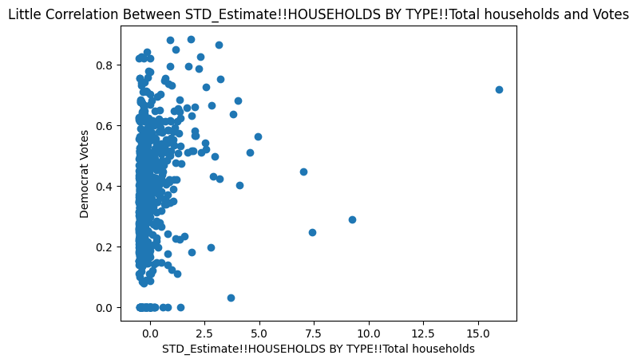

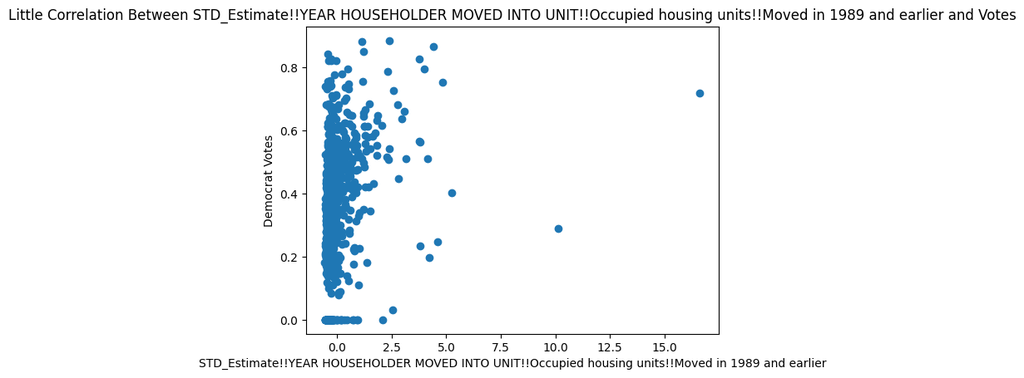

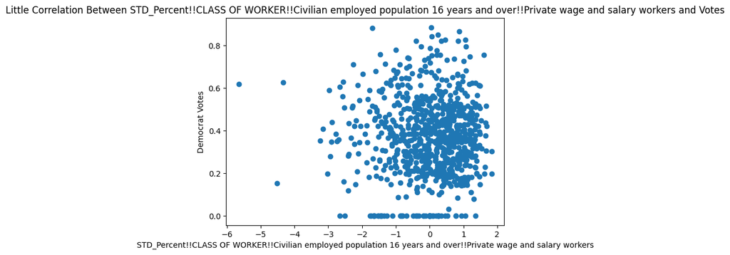

```python
import random
random_cols = random.sample(x_keys, 3)
for col in random_cols:
  plt.figure()
  plt.scatter(merged_df[col], merged_df['STD_Fraction_Dem'])
  plt.xlabel(col)
  plt.ylabel('Democrat Votes')
  plt.title('Little Correlation Between ' + col + ' and Votes')
```

There are far too many features in the census data to make any reasonable guess as to which is predictive. For example, these plots show three random features plotted against the democratic vote. And as you can see the average feature has no correlation so we need some additional method of determining feature importance.

# Data analysis and processing

Next, we used three different analysis tools to identify the top predictive features of a county's voting results: Lasso, PCA, and a Decision Tree.

## Lasso

We used a Lasso model to find which of the thousands of columns in the Census data best reflected a change in electoral results. We chose Lasso, rather than Ridge, since we hoped to shrink the less relevant predictors to zero to simplify our final predictive models. Given the significant number of Census data columns, we excluded some irrelevant categories, such as "marign of error" columns.

## Principal Component Analysis

Next, we did a preliminary Principal Component Analysis on the data. The purpose of this portion was to get to the fundemental question of the project, why did counties flip, by identifying principal components of the dataset.

## Decision Tree

Finally, we used a decision tree with max_depth of 5 for an alternative method of determining feature importance. We ultimately used both Lasso and Decision Tree feature importance data to both understand the factors which impact voting lines and also to build and compare predictive models.

## PCA

We used SciKit's scaling and PCA model to find the principal components of the data.

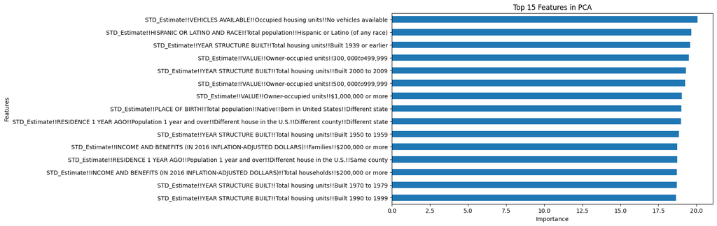

```python
pca = PCA()
X_pca = pca.fit_transform(merged_df[x_keys])
pca_components = pd.DataFrame(pca.components_, columns=merged_df[x_keys].columns)

feature_importance_pca = np.abs(pca_components).sum(axis=0).sort_values(ascending=False)
top_features_pca = feature_importance_pca.head(15)

#Plotting
plt.figure(figsize=(10,6))
top_features_pca.plot(kind='barh')
plt.title('Top 15 Features in PCA')
plt.ylabel('Features')
plt.xlabel('Importance')
plt.gca().invert_yaxis()
plt.show()
```

This was not particularly helpful because we passed into PCA so many variables. There were many variables that were, due to the somewhat random attribute they were measuring, neither correlated with the rest of the dataset nor related to the response. PCA rightly isolated these variables since there would be a minimal amount of colinearity, but because they have little explanatory value this is not helpful for choosing what variables we want to include in our further models of feature importance.

## Lasso

We used SciKit's Lasso model to find the most significant predictors for the `STD_Fraction_Dem` column.

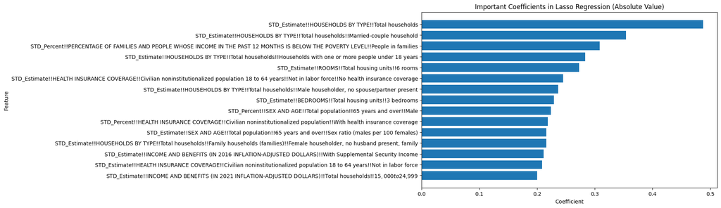

```python
# For now, pass the DataFrame and X keys directly to Lasso (useful to change these for testing).
merged_df_lasso = merged_df
x_keys_lasso = x_keys

lasso = linear_model.Lasso(alpha=0.000001)

# Now, fit the Lasso model
lasso = lasso.fit(merged_df_lasso[x_keys_lasso], merged_df_lasso[y_key])
coefficients = lasso.coef_

coefficients_dict = { key: abs(coefficients[i]) for i, key in enumerate(x_keys_lasso) }
keys_sorted_by_coefficient = sorted(x_keys_lasso, key=lambda key: -abs(coefficients_dict[key]))

coefficients_df = pd.DataFrame(list(coefficients_dict.items()), columns=['Feature', 'Coefficient'])
important_coef_lasso_df = coefficients_df[abs(coefficients_df['Coefficient']) > 0.20]
important_coef_lasso_df = important_coef_lasso_df.sort_values(by='Coefficient', ascending=False)

#Plotting
plt.figure(figsize=(10,6))
plt.barh(important_coef_lasso_df['Feature'], important_coef_lasso_df['Coefficient'])
plt.xlabel('Coefficient')
plt.ylabel('Feature')
plt.title('Important Coefficients in Lasso Regression (Absolute Value)')
plt.gca().invert_yaxis()
plt.show()
```

The most significant predictor by a significant margin was total household. Other significant predictors include married-couple household and people in families. Even with lasso, however, there were still not enough marked differences in the prediction power of our first fifteen variables to have an obvious cut-off point.

## Decision Tree Regresion for Feature Importance

Identifying the most importance features using a decision tree of depth = 5

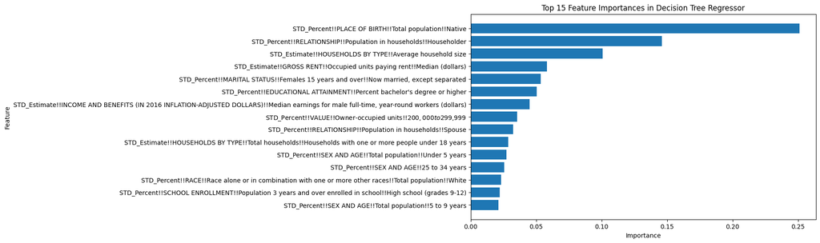

```python
# Model
dtree = DecisionTreeRegressor(max_depth=5, random_state=27)

# Fitting
dtree.fit(merged_df[x_keys], merged_df[y_key])
feature_importance = dtree.feature_importances_
important_coef_dt_df = pd.DataFrame({'Feature': merged_df[x_keys].columns, 'Importance': feature_importance})
important_coef_dt_df = important_coef_dt_df.sort_values(by='Importance', ascending=False).head(15)

# Plotting
plt.figure(figsize=(10,6))
plt.barh(important_coef_dt_df['Feature'], important_coef_dt_df['Importance'])
plt.xlabel('Importance')
plt.ylabel('Feature')
plt.title('Top 15 Feature Importances in Decision Tree Regressor')
plt.gca().invert_yaxis()
plt.show()
```

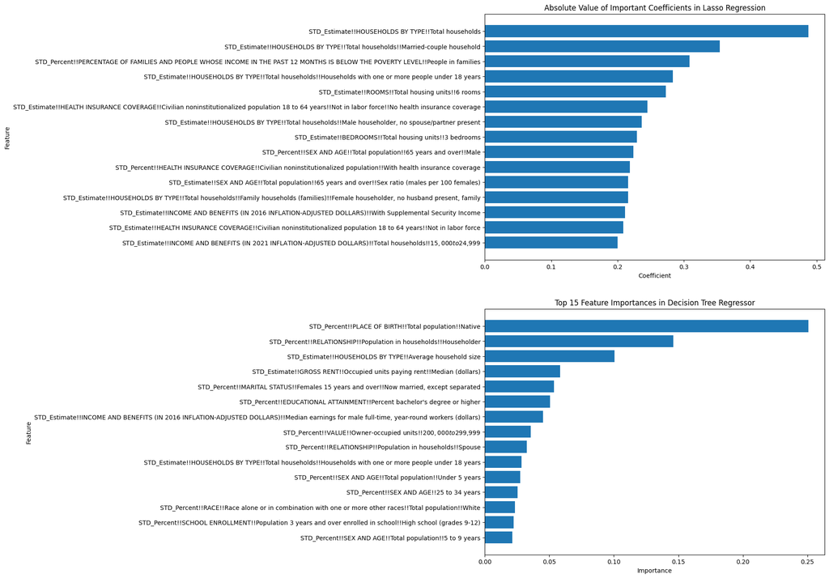

```python
# Direct comparison of two feature importance determiners
plt.figure(figsize=(10, 16))

# Decision Tree Regressor Feature Importances
plt.subplot(2, 1, 2)
plt.barh(important_coef_dt_df['Feature'], important_coef_dt_df['Importance'])
plt.xlabel('Importance')
plt.ylabel('Feature')
plt.title('Top 15 Feature Importances in Decision Tree Regressor')
plt.gca().invert_yaxis()

# Absolute value of Lasso Regression Coefficients
# Taking absolute value for a more direct visualization of importance
abs_important_coef_lasso_df = important_coef_lasso_df.sort_values(by='Coefficient', key=lambda x: x.abs(), ascending=False)
plt.subplot(2, 1, 1)
plt.barh(important_coef_lasso_df['Feature'], np.abs(abs_important_coef_lasso_df['Coefficient']))
plt.xlabel('Coefficient')
plt.ylabel('Feature')
plt.title('Absolute Value of Important Coefficients in Lasso Regression')
plt.gca().invert_yaxis()

plt.tight_layout()
plt.show()
```

# Predicting using different models

In the previous step, we used two different feature importance models to identify 15 most importance features in the dataset. In this step, we used those sets of 15 predictors to develop various models to predict the election outcomes.

## Random Forests

### Random Forest w/ Lasso Features

```python
important_predictors1 = important_coef_lasso_df['Feature']
print(important_predictors1)
X = merged_df[important_predictors1]
y = merged_df['STD_Fraction_Dem']
X_train, X_test, y_train, y_test = train_test_split(X, y, test_size=0.2, random_state=27)

regressor = RandomForestRegressor(max_depth=10, random_state=27)
regressor.fit(X_train, y_train)
y_pred = regressor.predict(X_test)

mseRFL = mean_squared_error(y_test, y_pred)
r2RFL = r2_score(y_test, y_pred)
print(f'Mean Squared Error: {mseRFL}')
print(f'R-squared: {r2RFL}')
```

```
0      STD_Estimate!!HOUSEHOLDS BY TYPE!!Total househ...
518    STD_Estimate!!HOUSEHOLDS BY TYPE!!Total househ...
289    STD_Percent!!PERCENTAGE OF FAMILIES AND PEOPLE...
530    STD_Estimate!!HOUSEHOLDS BY TYPE!!Total househ...
333    STD_Estimate!!ROOMS!!Total housing units!!6 rooms
271    STD_Estimate!!HEALTH INSURANCE COVERAGE!!Civil...
522    STD_Estimate!!HOUSEHOLDS BY TYPE!!Total househ...
350    STD_Estimate!!BEDROOMS!!Total housing units!!3...
726    STD_Percent!!SEX AND AGE!!Total population!!65...
228    STD_Percent!!HEALTH INSURANCE COVERAGE!!Civili...
700    STD_Estimate!!SEX AND AGE!!Total population!!6...
8      STD_Estimate!!HOUSEHOLDS BY TYPE!!Total househ...
190    STD_Estimate!!INCOME AND BENEFITS (IN 2016 INF...
263    STD_Estimate!!HEALTH INSURANCE COVERAGE!!Civil...
556    STD_Estimate!!INCOME AND BENEFITS (IN 2021 INF...
Name: Feature, dtype: object
Mean Squared Error: 0.027038124133447004
R-squared: 0.18206118995188092
```

### Random Forest w/ Decision Tree Features

```python
important_predictors_dt = important_coef_dt_df['Feature']
print(important_predictors_dt)
X = merged_df[important_predictors_dt]
y = merged_df['STD_Fraction_Dem']
X_train, X_test, y_train, y_test = train_test_split(X, y, test_size=0.2, random_state=27)

regressor = RandomForestRegressor(max_depth=10, random_state=27)
regressor.fit(X_train, y_train)
y_pred = regressor.predict(X_test)

mseRFDT = mean_squared_error(y_test, y_pred)
r2RFDT = r2_score(y_test, y_pred)
print(f'Mean Squared Error: {mseRFDT}')
print(f'R-squared: {r2RFDT}')
```

```
129    STD_Percent!!PLACE OF BIRTH!!Total population!...
25     STD_Percent!!RELATIONSHIP!!Population in house...
20     STD_Estimate!!HOUSEHOLDS BY TYPE!!Average hous...
445    STD_Estimate!!GROSS RENT!!Occupied units payin...
53     STD_Percent!!MARITAL STATUS!!Females 15 years ...
89     STD_Percent!!EDUCATIONAL ATTAINMENT!!Percent b...
223    STD_Estimate!!INCOME AND BENEFITS (IN 2016 INF...
403    STD_Percent!!VALUE!!Owner-occupied units!!$200...
27     STD_Percent!!RELATIONSHIP!!Population in house...
530    STD_Estimate!!HOUSEHOLDS BY TYPE!!Total househ...
703    STD_Percent!!SEX AND AGE!!Total population!!Un...
463             STD_Percent!!SEX AND AGE!!25 to 34 years
504    STD_Percent!!RACE!!Race alone or in combinatio...
69     STD_Percent!!SCHOOL ENROLLMENT!!Population 3 y...
704    STD_Percent!!SEX AND AGE!!Total population!!5 ...
Name: Feature, dtype: object
Mean Squared Error: 0.02135272771565751
R-squared: 0.35405190786067264
```

## W/ Gradient Boosting

### Gradient Boosting w/ Lasso Features

```python
important_predictors1 = important_coef_lasso_df['Feature']
X = merged_df[important_predictors1]
y = merged_df['STD_Fraction_Dem']
X_train, X_test, y_train, y_test = train_test_split(X, y, test_size=0.2, random_state=27)

gbr = GradientBoostingRegressor(max_depth=3, random_state=27)

gbr.fit(X_train, y_train)
y_pred = gbr.predict(X_test)

mseGBL = mean_squared_error(y_test, y_pred)
r2GBL = r2_score(y_test, y_pred)
print(f'Mean Squared Error: {mseGBL}')
print(f'R-squared: {r2GBL}')
```

```
Mean Squared Error: 0.029255235077034657
R-squared: 0.11499066841745842
```

### Gradient Boosting w/ Decision Tree Features

```python
important_predictors_dt = important_coef_dt_df['Feature']
print(list(important_predictors_dt[0:5]))
X = merged_df[important_predictors_dt]
y = merged_df['STD_Fraction_Dem']
X_train, X_test, y_train, y_test = train_test_split(X, y, test_size=0.2, random_state=27)

gbr = GradientBoostingRegressor(max_depth=3, random_state=27)
gbr.fit(X_train, y_train)
y_predGBDT = gbr.predict(X_test) # changed the variable name for plotting in "Results"

mseGBDT = mean_squared_error(y_test, y_predGBDT)
r2GBDT = r2_score(y_test, y_predGBDT)
print(f'Mean Squared Error: {mseGBDT}')
print(f'R-squared: {r2GBDT}')
```

```
['STD_Percent!!PLACE OF BIRTH!!Total population!!Native', 'STD_Percent!!RELATIONSHIP!!Population in households!!Householder', 'STD_Estimate!!HOUSEHOLDS BY TYPE!!Average household size', 'STD_Estimate!!GROSS RENT!!Occupied units paying rent!!Median (dollars)', 'STD_Percent!!MARITAL STATUS!!Females 15…
Mean Squared Error: 0.020183076963319502
R-squared: 0.38943538120436394
```

```python
pt = PrettyTable()
pt.field_names = ["Model","MSE","R^2"]
pt.add_row(["Random Forest - Lasso Feature Selection",mseRFL,r2RFL])
pt.add_row(["Random Forest - Decision Tree Feature Selection",mseRFDT,r2RFDT])
pt.add_row(["Gradient Boosting - Lasso Feature Selection",mseGBL,r2GBL])
pt.add_row(["Gradient Boosting - Decision Tree Feature Selection",mseGBDT,r2GBDT])
print(pt)
```

```
+-----------------------------------------------------+----------------------+---------------------+
|                        Model                        |         MSE          |         R^2         |
+-----------------------------------------------------+----------------------+---------------------+
|       Random Forest - Lasso Feature Selection       | 0.027038124133447004 | 0.18206118995188092 |
|   Random Forest - Decision Tree Feature Selection   | 0.02135272771565751  | 0.35405190786067264 |
|     Gradient Boosting - Lasso Feature Selection     | 0.029255235077034657 | 0.11499066841745842 |
| Gradient Boosting - Decision Tree Feature Selection | 0.020183076963319502 | 0.38943538120436394 |
+-----------------------------------------------------+----------------------+---------------------+
```

Gradient Boosting w/ Decision Tree Feature Selection shows the best performance among the four. It has the lowest MSE, indicating the highest accuracy in predictions as well as the highest R² value, suggesting it's the most effective at explaining about 39% of variance.

### Results

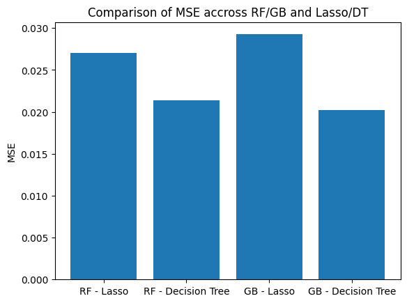

```python
plt.bar(
    [
        "RF - Lasso",
        "RF - Decision Tree",
        "GB - Lasso",
        "GB - Decision Tree"
    ],
    [mseRFL, mseRFDT, mseGBL, mseGBDT]
)
plt.ylabel('MSE')
plt.title('Comparison of MSE accross RF/GB and Lasso/DT')
```